# Linear Regression

We try to find the corelation between two variables.

## Target - Find the correlation between ages and hourly wages.

### Model 1 - Simple Linear Regression

#### Idea

We aim to use simple linear regression to model the relationship between age (`AGE_12`) as the independent variable (feature) and hourly wages (`HRLYEARN`) as the dependent variable (target). The regression model will predict hourly wages based on age.

The process involves:

1. Splitting the cleaned data into training and testing sets.
2. Training a linear regression model on the training set.
3. Evaluating the model by predicting hourly wages for the test set.
4. Visualizing the results with a scatter plot of actual vs. predicted values.

#### Issues & Troubleshooting

- Issue: "ValueError: Input y contains NaN"
  - Reason: There is "NaN" in the data.
  - Solution: Use `dropna()` to remove the rows with NaN values.
- Issue: "TypeError: can only concatenate str (not "int") to str"
  - Reason: The column index is a string, and we are trying to use it as an integer.
  - Solution: Convert the column index to numeric.
- Issue: The units in the graph are confusing.
  - Reason: Units don't mapped to real-world values.
  - Solution: Read label mapping from another file (REF_TABLE).
- Issue: Logic become complicated after adding mapping.
  - Reason: Data unifying is mixed with data processing.
  - Solution: Separate data unifying and data processing into different functions.

#### Result Evaluation

We use several metrics to evaluate the model's performance:

- MAE (Mean Absolute Error)
  - The average of the absolute differences between predicted and actual values.
  - This metric gives us an idea of how far off our predictions are from the actual values.
  - The value range is from 0 to infinity, lower is better.
- MSE (Mean Squared Error)
  - The average of the squared differences between predicted and actual values.
  - Compared to MAE, MSE gives more weight to larger errors, making it sensitive to outliers.
  - The value range is from 0 to infinity, lower is better.
- Mean Error
  - RMSE (Root Mean Squared Error) with Percentage Error Relative to Mean Prediction.
  - It provides a normalized measure of the error as a percentage of the average predicted value.
  - The value range is from 0% to 100%, lower is better.

The mean error is 52.3%, which is not accurate enough for a linear regression model. This indicates that the model's predictions are, on average, 52.3% off from the actual hourly wages.

But we can still get some insights from the graph. The wages are increasing with age in a general sense. This may caused by the fact that older people have more experience and are more likely having a higher position in the company.

#### Code & Explanation

Import necessary libraries.

```python
import numpy as np
import pandas as pd
import matplotlib.pyplot as plt
from sklearn import linear_model, model_selection
from sklearn.metrics import mean_squared_error
```

Load data.

```python
WAGE_0225 = "../data/pub0225.csv"
wage_df = pd.DataFrame(pd.read_csv(WAGE_0225))
```

Load reference table.

```python
REF_TABLE = "../data/LFS_PUMF_EPA_FGMD_codebook_formatted.xlsx"
ref_df = pd.DataFrame(pd.read_excel(REF_TABLE))
ref_df_lower = ref_df.map(lambda x: x.lower() if isinstance(x, str) else x)
```

Get mapping between "column name" and "human readable name".

```python
def get_human_name(col: str) -> str:
    """
    Get the human-readable name for a given column.
    """
    col_lower = col.lower()

    locations = ref_df_lower[ref_df_lower.isin([col_lower])].stack().index
    if len(locations) != 1:
        raise ValueError(
            f"expected 1 location for {col_lower}, found {len(locations)}"
        )

    location = locations[0]
    row_index, col_index = location

    # Convert column index to integer if it's a string.
    if isinstance(col_index, str):
        col_index = ref_df_lower.columns.get_loc(col_index)

    mapped_label = ref_df_lower.loc[row_index, ref_df_lower.columns[col_index + 1]]
    return mapped_label

column_names = wage_df.columns.tolist()
column_name_map = dict()
for col in column_names:
    try:
        human_name = get_human_name(col)
        column_name_map[col] = human_name
    except ValueError:
        pass
print(column_names)
print(column_name_map)
```

```
['REC_NUM', 'SURVYEAR', 'SURVMNTH', 'LFSSTAT', 'PROV', 'CMA', 'AGE_12', 'AGE_6', 'GENDER', 'MARSTAT', 'EDUC', 'MJH', 'EVERWORK', 'FTPTLAST', 'COWMAIN', 'IMMIG', 'NAICS_21', 'NOC_10', 'NOC_43', 'YABSENT', 'WKSAWAY', 'PAYAWAY', 'UHRSMAIN', 'AHRSMAIN', 'FTPTMAIN', 'UTOTHRS', 'ATOTHRS', 'HRSAWAY', 'YAWA…
{'REC_NUM': 'order of record in file', 'SURVYEAR': 'survey year', 'SURVMNTH': 'survey month', 'PROV': 'province', 'CMA': 'nine largest cmas', 'AGE_12': 'five-year age group of respondent', 'GENDER': 'gender of respondent', 'MARSTAT': 'marital status of respondent', 'EDUC': 'highest educational attai…
```

Unify data.

```python
def unify(df: pd.DataFrame) -> pd.DataFrame:
    """
    Unify the DataFrame by applying suitable transformations to each column.

    Args:
        df (pd.DataFrame): The DataFrame to unify.

    Returns:
        pd.DataFrame: The unified DataFrame.
    """
    df["HRLYEARN"] = df["HRLYEARN"] / 100
    return df

wage_df = unify(wage_df)
print(wage_df["HRLYEARN"].head())
```

```
0      NaN
1    43.71
2    60.10
3      NaN
4    90.30
Name: HRLYEARN, dtype: float64
```

Run regression.

```
got a DataFrame with 113780 rows and 60 columns
run linear regression, feature: AGE_12, target: HRLYEARN
dropped missing values, now working with 57015 rows
feature shape: (57015, 1), target shape: (57015,)
training feature shape: (38200, 1), training target shape: (38200,)
```

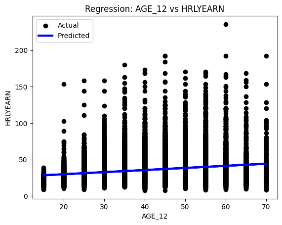

```
mean error: 18.6 (52.3%)
```

|  | Coefficient | Intercept |
| --- | --- | --- |
| 0 | 0.288442 | 24.018332 |

```python
def regression(df: pd.DataFrame, feature_column: str, target_column: str):
    """
    Perform regression analysis on the given DataFrame.

    Args:
        df (pd.DataFrame): The DataFrame containing the data.
        feature_column (str): The name of the feature column.
        target_column (str): The name of the target column.

    Returns:
        pd.DataFrame: The modified DataFrame with regression results.
    """
    print(f"got a DataFrame with {df.shape[0]} rows and {df.shape[1]} columns")
    print(f"run linear regression, feature: {feature_column}, target: {target_column}")

    df_cleaned = df.dropna(subset=[feature_column, target_column])
    print(f"dropped missing values, now working with {df_cleaned.shape[0]} rows")

    feature = df_cleaned[[feature_column]].values.reshape(-1, 1)
    feature = 10 + feature * 5
    target = df_cleaned[target_column].values

    print(f"feature shape: {feature.shape}, target shape: {target.shape}")

    # 1. Splitting the cleaned data into training and testing sets.
    feature_train, feature_test, target_train, target_test = (
        model_selection.train_test_split(
            feature, target, test_size=0.33, random_state=42
        )
    )

    print(
        f"training feature shape: {feature_train.shape}, training target shape: {target_train.shape}"
    )

    # 2. Training a linear regression model on the training set.
    model = linear_model.LinearRegression()
    model.fit(feature_train, target_train)

    # 3. Evaluating the model by predicting hourly wages for the test set.
    target_pred = model.predict(feature_test)

    # 4. Visualizing the results with a scatter plot of actual vs. predicted values.
    plt.scatter(feature_test, target_test, color="black", label="Actual")
    plt.plot(feature_test, target_pred, color="blue", linewidth=3, label="Predicted")
    plt.xlabel(feature_column)
    plt.ylabel(target_column)
    plt.title(f"Regression: {feature_column} vs {target_column}")
    plt.legend()
    plt.show()

    rmse = np.sqrt(mean_squared_error(target_test, target_pred))
    print(f"mean error: {rmse:3.3} ({rmse/np.mean(target_pred)*100:3.3}%)")

    results = pd.DataFrame(
        {"Coefficient": model.coef_, "Intercept": [model.intercept_]}
    )
    return results


regression(wage_df, "AGE_12", "HRLYEARN")
```

```python
# 0

#     human_name, value_map = get_label_map("AGE_12", 12)

#     # convert keys to int
#     value_map = {int(k): v for k, v in value_map.items()}

#     # apply the mapping to the "AGE_12" column
#     df["AGE_12"] = df["AGE_12"].map(value_map)

#     column = df["AGE_12"]
#     print(f"{column[:5]}")

#     # rename the column to the human-readable name
#     # df.rename(columns={"AGE_12": human_name}, inplace=True)

#     # print(f"renamed AGE_12 to {human_name}")

#     # column = df[human_name]
#     # print(f"{column[:5]}")

#     return df


def get_label_map(origin_label: str, rows: int) -> tuple[str, dict]:
    """
    Read rows below the "origin_label" in the DataFrame and the column
    in the right, then create a label map.

    Args:
        df (pd.DataFrame): The DataFrame containing the data.
        origin_label (str): The label to start reading from.
        rows (int): The number of rows to read.

    Returns:
        mapped_label (str): The mapped label.
        label_map (dict): A dictionary mapping labels from origin_label to mapped labels.
    """
    REF_TABLE = "../data/LFS_PUMF_EPA_FGMD_codebook_formatted.xlsx"
    df = pd.DataFrame(pd.read_excel(REF_TABLE))

    df_lower = df.map(lambda x: x.lower() if isinstance(x, str) else x)
    origin_label_lower = origin_label.lower()

    locations = df_lower[df.isin([origin_label_lower])].stack().index
    if len(locations) != 1:
        raise ValueError(
            f"expected 1 location for {origin_label_lower}, found {len(locations)}"
        )

    location = locations[0]
    row_index, col_index = location
    print(f"found age_12 at row {row_index}, column {col_index}")

    # Convert column index to integer if it's a string.
    if isinstance(col_index, str):
        col_index = df.columns.get_loc(col_index)

    mapped_label = df.loc[row_index, df.columns[col_index + 1]]

    origin_values = df.loc[row_index + 1 : row_index + rows, df.columns[col_index]]

    mapped_values = df.loc[row_index + 1 : row_index + rows, df.columns[col_index + 1]]

    label_map = dict(zip(origin_values, mapped_values))
    return mapped_label, label_map


df_unified = unify(df)
```